# 15_B_Simple_Exponential_Smoothing - Theory

# References

1. Hyndman, R.J., & Athanasopoulos, G., 2021. *Forecasting: principles and practice*. 3rd edition.
2. Associated .pdf file *06_1_A_SES_equations.pdf* (very important).
3. Associated video lesson explaining the .pdf file ([Link](https://youtu.be/zlfbuwgfsq4))
4. Fable package documentation
- https://fable.tidyverts.org/index.html
- https://fable.tidyverts.org/articles/fable.html

# Note

This notebook is not original material, but rather based on ref. 1 with notes expanding on some of the concepts contained in the book.

# Libraries

```r
library(fpp3)
library(patchwork) # to easily place graphs next to each other
```

# Intro

**Exponential smoothing forecasts: the main idea**

- **Mean method**: constant forecasts. Every observation gets the same weight.
- **Naive method**: constant forecasts. All the weight goes to the last observation.
- **Exponential smoothing**: also constant forecasts, but from a weighted average of the past observations, with weights that decay exponentially as the observations get older.
  - The more recent the observation, the larger its weight.

# Simple exponential smoothing (SES)

It produces **constant forecasts**, so it suits data with **no clear trend or seasonal pattern**.

Example:

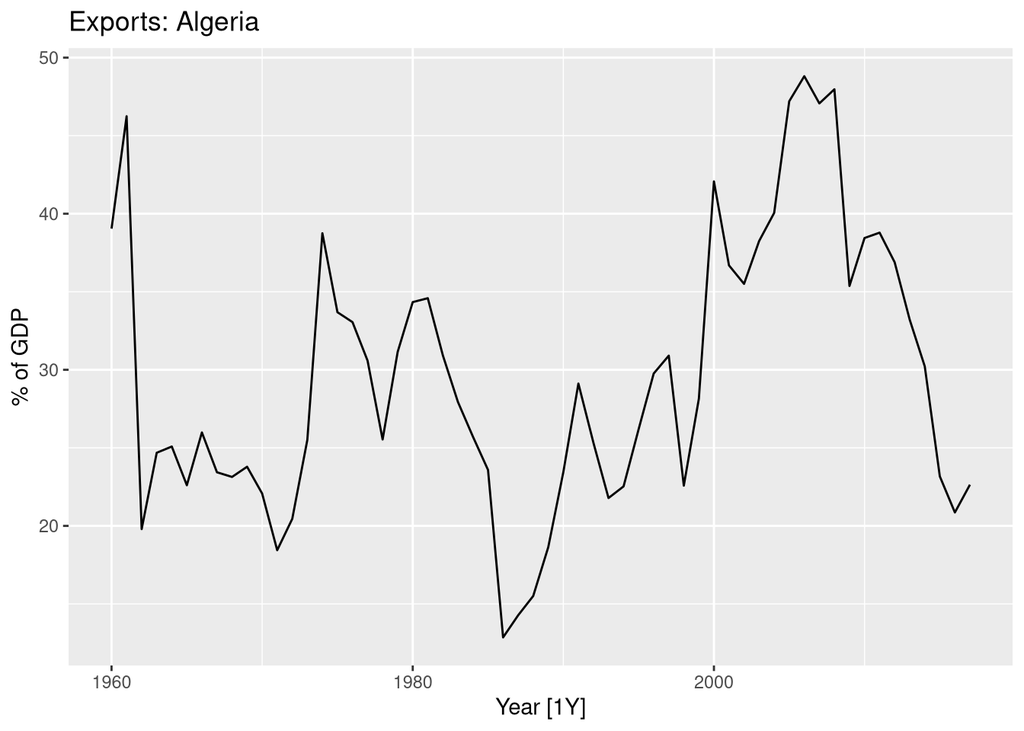

```r
algeria_economy <- global_economy |>
  filter(Country == "Algeria")

algeria_economy |>
  autoplot(Exports) +
  labs(y = "% of GDP", title = "Exports: Algeria")
```

The data above has no clear trend or seasonality. Among the benchmark methods, the **naïve or the mean method** would suit it.

## Naïve vs. mean vs. simple exponential smoothing

### Naïve

All future forecasts equal the last observed value. **Only the most recent observation matters.**

$$\hat{y}_{T+h|T} = y_{T}$$

- for $h = 1, 2, \dots$

### Mean method

All future forecasts equal the simple average of the observed data. **Every observation matters equally: all get the same weight.**

$$\hat{y}_{T+h|T} = \frac1T \sum_{t=1}^T y_t$$

- for $h = 1, 2, \dots$

## Simple exponential smoothing

Between the naive and the mean method.

- Forecasts are weighted averages.
- More recent observations have larger weights.
- The weights come from a geometric sequence.
- They decrease exponentially the further in the past the observation lies.

$$\hat{y}_{T+1|T} = \alpha y_T + \alpha(1-\alpha) y_{T-1} + \alpha(1-\alpha)^2 y_{T-2}+ \cdots = \sum_{j=0}^{T-1} \alpha(1-\alpha)^j y_{T-j}$$
The weights of simple exponential smoothing follow a geometric sequence with ratio $1 - \alpha$. For this sequence (see the deck `15_A` in this session’s folder):

1. $a_1 = \alpha \in (0,1]$
2. $r = (1-\alpha) \in (0,1]$
3. $a_n = \alpha(1-\alpha)^{n-1}$ (general term of the sequence).
   - This means that the **coefficients used by simple exponential smoothing decrease exponentially, as desired**.
4. $S_n = \sum_{j=1}^{n}a_n\rightarrow 1$ if $n \rightarrow \infty$ (sum of the coefficients converges to 1).
   - The coefficients of simple exponential smoothing add up to 1, as one would expect from a weighted average.

Points 3 and 4 are proved in `15_A`. They are basic properties of the geometric sequence behind SES, and you should be able to derive them.

### Flat forecasts of simple exponential smoothing

By design, Simple Exponential Smoothing has a “flat” forecast function. **All forecasts beyond the training data take the same value.**

If $t=T$ is the last point in time of the training data, this means that:

$$\hat{y}_{T+h|T} = \hat{y}_{T+1|T} = \sum_{j=0}^{T-1} \alpha(1-\alpha)^j y_{T-j} \qquad h=2,3,\dots.$$

So these forecasts only suit a **series with no trend and no seasonal component**.

The **fitted values**, on the other hand, are not constant. Each is a *one-step-ahead forecast* based on all the preceding observations.

### Component form of the equations

Together, the *forecast equation* and the *smoothing equation* are the **component form of simple exponential smoothing**. This form is equivalent to the weighted average form: it is derived from it, as `15_A` shows.

$$\begin{align*}
\text{Forecast equation} && \hat{y}_{T+h|T} & = \ell_{T}\\
\text{Smoothing equation} && \ell_{t} & = \alpha y_{t} + (1 - \alpha)\ell_{t-1},
\end{align*}$$
where:

- $\hat{y}_{T+h|T}$ is the forecast at $T+h$ given everything occurred up to $T$, with $T$ being the last point in the training data.
- $\alpha$ is the smoothing parameter of the model.
- $l_t$ is the level of the time series at time $t$.

### Equations for the fitted values

By definition, fitted values are *one-step-ahead forecasts on the training data*: $\hat{y}_{t|t-1}$.

To get the equations for the fitted values from the component form, set $h=1$:

$$\begin{align*}
\text{Forecast equation at t=T+1 (with h=1)} && \hat{y}_{T+1|T} & = \ell_{T}\\
\text{Smoothing equation at t=t} && \ell_{t} & = \alpha y_{t} + (1 - \alpha)\ell_{t-1},
\end{align*}$$

To apply both equations at a generic point in time $t$, both must refer to that point. So we make the **change of variable** $t=T+1 \rightarrow T=t-1$ in the forecast equation: replace $T$ with $t-1$. The equations become:

$$\begin{align*}
\text{Forecast equation at t=t (with h=1)} && \hat{y}_{t|t-1} & = \ell_{t-1}\\
\text{Smoothing equation at t=t} && \ell_{t} & = \alpha y_{t} + (1 - \alpha)\ell_{t-1},
\end{align*}$$

Together, these two equations give the **fitted values**: given $\alpha$ and $l_0$, they compute the fitted value at every point $t=1, 2, \cdots, T$.

$$\begin{align*}
\text{Equation for fitted value at t=t} && \hat{y}_{t|t-1} & = \ell_{t-1}\\
\text{Smoothing equation at t=t} && \ell_{t} & = \alpha y_{t} + (1 - \alpha)\ell_{t-1},
\end{align*}$$

For further details, see `15_A` and the explanations given in class.

### Finding the best values for $l_0$ and $\alpha$, that is, fitting the model

To apply simple exponential smoothing, two values must be chosen:

- $\alpha$: the smoothing parameter
- $l_0$: the initial value of $l_t$

More complex exponential smoothing methods have more than one smoothing parameter and more than one initial component.

**Choice of parameters**

- Sometimes past experience guides the choice.
- Usually the observed data is used to estimate them:
  - the parameters are chosen to minimize the **sum of squared residuals**.
    - NOTE: the **sum of squared residuals** is usually called the **sum of squared errors (SSE)**, although residuals $\neq$ errors, strictly speaking (see the session on benchmark methods and fitted values).

$$\text{Residuals} = e_t=y_t - \hat{y}_{t|t-1}$$

$$\text{SSE} = \sum_{t=1}^T(y_t - \hat{y}_{t|t-1})^2=\sum_{t=1}^Te_t^2.$$

For simple exponential smoothing this optimization problem has no explicit solution, so it is solved numerically: an iterative search for the values of $\alpha$ and $l_0$ that minimize the SSE. In outline:

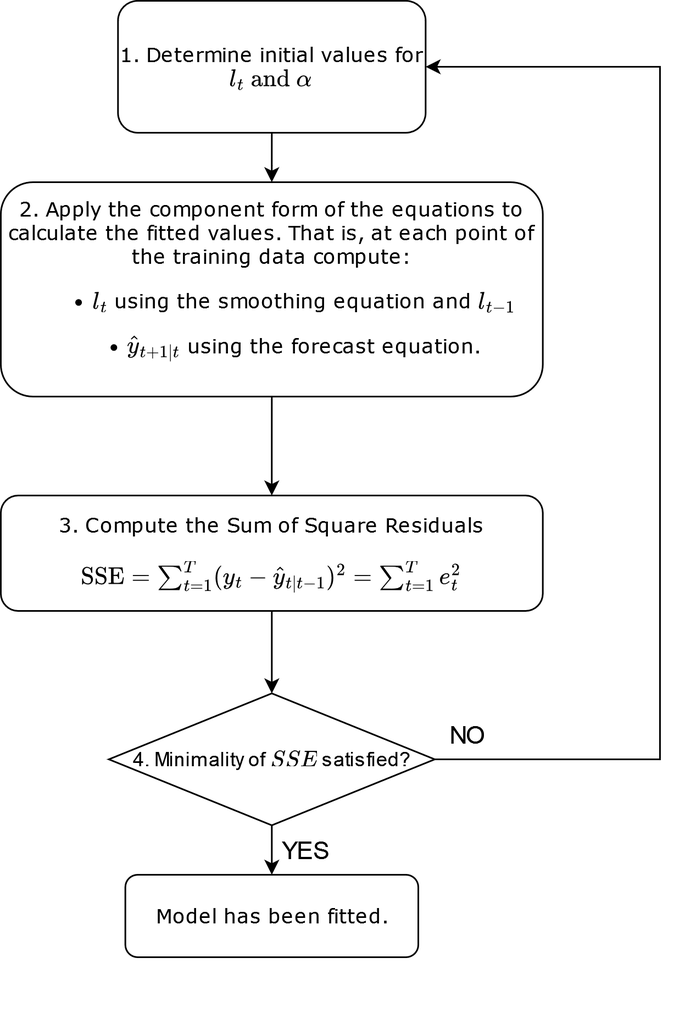

You may recall that linear regression has explicit formulas for the values that minimize the SSE. SES does not.

**Step 2 of the fitting process** is **computing the fitted values from $\alpha$ and $l_0$ with the component equations.** The Excel workbook `15_C` in this session’s folder walks through this step by hand; filling it in is the homework.

## Model specification in `fable`: an example

As forecasters, we want to use this model in R, specifically with the `fpp3` packages. It is simple.

### 1. Fitting the model

Exponential smoothing methods are fitted with the `ETS()` function of the `fable` package. `ETS` stands for two things:

1. *E*xponen*T*ial *S*moothing.
2. *Error*, *Trend*, *Season*: the three parts of the model formula, as the examples show. The later forms of exponential smoothing add `trend` and `seasonality`.

Two functions fit an `ETS()` model:

- **`model()`** (also from `fable`) trains the model definition on a dataset.
- **`ETS()`** returns the model definition given by its formula.

The details are in `?ETS` and `?model`, but an example is the best way in.

We return to the Algerian exports from before. For **simple exponential smoothing** use **“A”, “N” and “N” for `error()`, `trend()` and `season()`**.

```r
# Estimate parameters
fit <- algeria_economy |>
  model(ETS(Exports ~ error("A") + trend("N") + season("N")))
```

### 2. Computing the fitted values

Once the model is fitted, `augment()` gives the fitted values and the residuals, as usual:

```r
fitted_vals <-
  fit |> augment() |> select(Year, Exports, .fitted)

fitted_vals
```

```
# A tsibble: 58 x 3 [1Y]
    Year Exports .fitted
   <dbl>   <dbl>   <dbl>
 1  1960    39.0    39.5
 2  1961    46.2    39.1
 3  1962    19.8    45.1
 4  1963    24.7    23.8
 5  1964    25.1    24.6
 6  1965    22.6    25.0
 7  1966    26.0    23.0
 8  1967    23.4    25.5
 9  1968    23.1    23.8
10  1969    23.8    23.2
# ℹ 48 more rows
```

### 3. Interpreting the parameters

Remember that fitting the model chose the values of $\alpha$ and $l_{0}$ (the initial level) by minimizing the sum of squared errors. These are the parameters of simple exponential smoothing, and `tidy()` returns them:

```r
# Print out the model parameters
ses_params <- tidy(fit)
ses_params
```

```
# A tibble: 2 × 4
  Country .model                                                  term  estimate
  <fct>   <chr>                                                   <chr>    <dbl>
1 Algeria "ETS(Exports ~ error(\"A\") + trend(\"N\") + season(\"… alpha    0.840
2 Algeria "ETS(Exports ~ error(\"A\") + trend(\"N\") + season(\"… l[0]    39.5
```

```r
# Store alpha
alpha <- ses_params$estimate[1]
```

In this case we have $\alpha = 0.84$ and $l_{0} = 39.54$.

With $\alpha$ we can look at the weights of the different observations. Remember the weighted average form, equation $(1)$:

$$\hat{y}_{T+1|T} = \alpha y_T + \alpha(1-\alpha) y_{T-1} + \alpha(1-\alpha)^2 y_{T-2}+ \cdots = \sum_{j=0}^{T-1} \alpha(1-\alpha)^j y_{T-j} \tag{1}$$

The weight of the observation $y_{T-j}$ is therefore:

$$\alpha(1-\alpha)^j$$
With this formula, a `for` loop over the length of the series computes the weight of each observation:

```r
weights <- vector("double")
for (i in seq_len(nrow(fitted_vals))) {
  # Weight of the observation i steps before the forecast origin
  weights[[i]] <- alpha * (1 - alpha)^(i - 1)
}

# Add this column to the fitted values
fitted_vals$weight = rev(weights)

# Reverse the order of the dataframe to depict it more clearly
fitted_vals <-
  fitted_vals |> arrange(desc(Year))
fitted_vals
```

```
# A tsibble: 58 x 4 [1Y]
    Year Exports .fitted       weight
   <dbl>   <dbl>   <dbl>        <dbl>
 1  2017    22.6    21.4 0.840
 2  2016    20.9    24.4 0.134
 3  2015    23.2    30.8 0.0215
 4  2014    30.2    33.8 0.00344
 5  2013    33.2    37.2 0.000551
 6  2012    36.9    38.7 0.0000881
 7  2011    38.8    38.3 0.0000141
 8  2010    38.4    37.4 0.00000226
 9  2009    35.4    47.9 0.000000361
10  2008    48.0    47.3 0.0000000578
# ℹ 48 more rows
```

The most recent observation gets a weight of $\alpha = 0.8399$. The 2016 observation gets $\alpha(1-\alpha)=0.1344$, the 2015 observation $\alpha(1-\alpha)^2 = 0.0215$, and so on.

Together, these three observations get a weight of:

```r
sum(fitted_vals$weight[1:3])
```

```
[1] 0.995903
```

The rest, up to 1, is spread over all the other observations. As expected:

- More recent observations get more weight.
- Observations further in the past get weights that shrink exponentially.

As a final check, the sum of the weights should be very close to 1 (the sum of the sequence tends to 1 as $n$ grows):

```r
sum(fitted_vals$weight)
```

```
[1] 1
```

### 4. Reconstructing the fitted values from $\alpha$ and $l_0$

With the component form and the estimates of $\alpha$ and $l_0$ returned by the model, we can compute the fitted values ourselves. This is step 2 of the last iteration of the SSE minimization. Look at the diagram again:

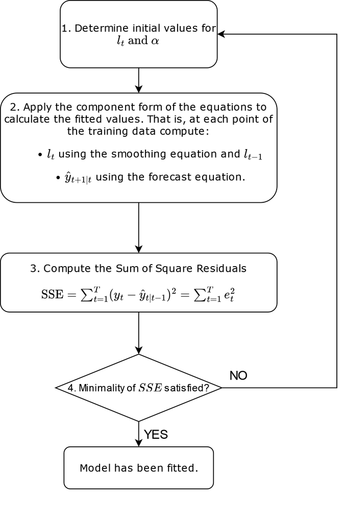

Since

- fitted values are one-step forecasts on the training data, $\hat{y}_{t|t-1}$, and
- the initial level $l_0$ was chosen by minimizing the sum of squared errors,

we can set $h=1$ in the component form and compute the fitted values in the table that follows:

$$\begin{align*}
\text{Forecast equation} && \hat{y}_{t+1|t} & = \ell_{t}\\
\text{Smoothing equation} && \ell_{t} & = \alpha y_{t} + (1 - \alpha)\ell_{t-1},
\end{align*}$$

| Year | Time | Observation | Level | Forecast |
| --- | --- | --- | --- | --- |
|  | $t$ | $y_t$ | $l_t$ | $\hat{y}_{t\|t-1}$ |
| 1959 | 0 |  | 39.54 |  |
| 1960 | 1 | 39.04 | 39.12 | 39.54 |
| 1961 | 2 | 46.24 | 45.10 | 39.12 |
| 1962 | 3 | 19.79 | 23.84 | 45.10 |
| 1963 | 4 | 24.68 | 24.55 | 23.84 |
| 1964 | 5 | 25.08 | 25.00 | 24.55 |
| 1965 | 6 | 22.60 | 22.99 | 25.00 |
| 1966 | 7 | 25.99 | 25.51 | 22.99 |
| 1967 | 8 | 23.43 | 23.77 | 25.51 |
|  | ⋮ | ⋮ | ⋮ | ⋮ |
| 2014 | 55 | 30.22 | 30.80 | 33.85 |
| 2015 | 56 | 23.17 | 24.39 | 30.80 |
| 2016 | 57 | 20.86 | 21.43 | 24.39 |
| 2017 | 58 | 22.64 | 22.44 | 21.43 |

#### Exercise

Use the Excel workbook `15_C` in this session’s folder to compute this table. That is the homework.

### 5. Computing forecasts

Once the model is fitted, forecasts come from the usual syntax:

```r
# Generate 5 step forecasts
fc <- fit |>
  forecast(h = 5)
```

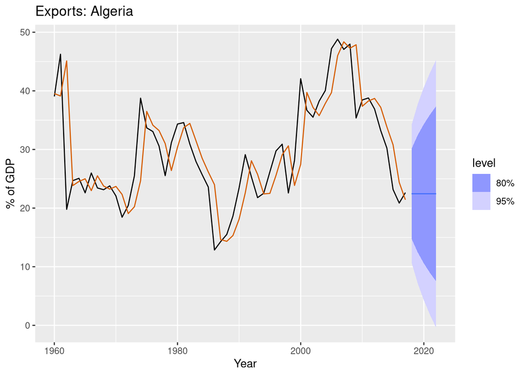

```r
fc |>
  autoplot(algeria_economy) +
  geom_line(aes(y = .fitted), col="#D55E00",
            data = augment(fit)) +
  labs(y="% of GDP", title="Exports: Algeria") +
  guides(colour = "none")
```

A similar table for the forecasts:

| Year | Time | Observation | Level | Forecast |
| --- | --- | --- | --- | --- |
|  | $h$ |  |  | $\hat{y}_{T+h\vert{T}}$ |
| 2018 | 1 |  |  | 22.44 |
| 2019 | 2 |  |  | 22.44 |
| 2020 | 3 |  |  | 22.44 |
| 2021 | 4 |  |  | 22.44 |
| 2022 | 5 |  |  | 22.44 |

Beyond the training data, the forecasts of simple exponential smoothing are flat. That is by design.

# Summary of SES

- Between the **naïve** and the **mean** method.
- **Produces constant (flat) forecasts by design:** $\hat{y}_{T+h|T}=\hat{y}_{T+1|T}$.
  - So it suits **data with no clear trend or seasonal pattern**.
- More recent observations have larger weights.
- The weights decrease exponentially the further in the past an observation lies.
  - They come from a geometric sequence:
    1. $a_1 = \alpha \in (0,1]$
    2. $r = (1-\alpha) \in (0,1]$
    3. $a_n = \alpha(1-\alpha)^{n-1}$ (general term of the sequence).
       - This means that the **coefficients used by simple exponential smoothing decrease exponentially, as desired**.
    4. $S_n = \sum_{j=1}^{n}a_n\rightarrow 1$ if $n \rightarrow \infty$ (sum of the coefficients converges to 1).
       - The coefficients of simple exponential smoothing add up to 1, as one would expect from a weighted average.
- Fitting the model means minimizing the SSE to find $\alpha$ and $l_{0}$, the model parameters.
- This optimization is performed automatically by the `fable()` library, with the possibility of tweaking the optimization criteria (this will be seen in the next semester).